# ass1

Tiffany Nguyen

2025-02-03

# Questions done: 15/15!

## ᓚᘏᗢ … DATA and FUNCTIONS .. ᘛ⁐̤ᕐᐷ

```r
library(Intro2R)
```

```r
library(ggplot2)
library(dplyr)
library(plotrix)
source("pareto.R")
dird="/Users/tiffanynguyen/Documents/College/Sophomore/Spring_2025/Applied_Statistical_Methods/data/K25936_Downloads/Excel/"
myread=function(csv){
  fl=paste(dird,csv,sep="")
  read.table(fl,header=TRUE,sep=",")
}
getmode <- function(v) {
   uniqv <- unique(v)
   uniqv[which.max(tabulate(match(v, uniqv)))]
}
eq <- myread("EARTHQUAKE.csv")
mtbe <- myread("MTBE.csv")
swd <- myread("SWDEFECTS.csv")
volt <- myread("VOLTAGE.csv")
pipe <- myread("ROUGHPIPE.csv")
ant <- myread("GOBIANTS.csv")
gal <- myread("GALAXY2.csv")
```

## Question 1

Final grade will be calculated as follows:

- 15% - 4 assignments (each 3.75%)
- 10% - Laboratories
- 10% - 2 projects (1st Project 3.33% (10/3), 2nd Project 6.67% (20/3))
- 10% - In-class quizzes
- 5% - Online chapter quizzes
- 20% - Midterm
- 30% - Final

Grade scale:

- A - [90%-100%]
- B - [80%-90%)
- C - [60%-80%)
- D - [50%-60%)
- F - < 50%

How to work out final grades:

1. Calculate the average grade (in percent) for each category
2. Multiply the average grade by its categorical weight
3. Sum the results from step 2 to get the final grade

## Question 2

### a

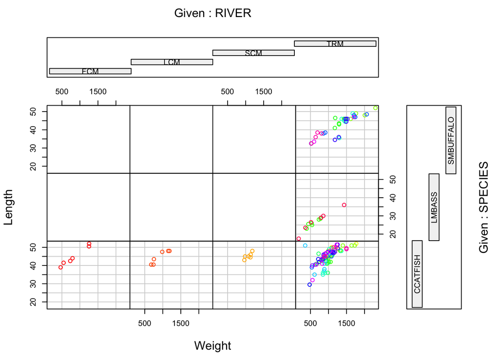

```r
# d <- read.table("DDT.csv", header=TRUE, sep=",")
r <- rainbow(length(unique(ddt$MILE)))
m=with(ddt, as.numeric(factor(MILE)))
coplot(LENGTH ~ WEIGHT | RIVER * SPECIES,
       data=ddt,
       xlab="Weight",
       ylab="Length",
       col=rep(r, table(ddt$MILE)),
       pch=21
       )
```

### b

```r
# y ~ x + I(x^2) : I is "as is" operator and the carrot should be done algebraically
# quadlm <- lm(y ~ x + I(x^2), data)
# summary (quadlm)

m=with(ddt, as.numeric(factor(MILE)))
length(unique(m))
```

```
## [1] 17
```

The lower left three conditional plots represent CCATFISH in rivers FCM, LCM, and SCM. There seems to be an increasing linear trend/relationship between length and weight.

### c

Line A basically creates a numeric representation of mile for each row in ddt, and maps it accordingly.

### d

Line B counts the number of unique numeric values from line A

### e

The top 6 plots are empty because there is no data for LMBASS and SMBUFFALO in rivers FCM, LCM, and SCM.

### f

```r
head(ddt)
```

```
##   RIVER MILE  SPECIES LENGTH WEIGHT DDT
## 1   FCM    5 CCATFISH   42.5    732  10
## 2   FCM    5 CCATFISH   44.0    795  16
## 3   FCM    5 CCATFISH   41.5    547  23
## 4   FCM    5 CCATFISH   39.0    465  21
## 5   FCM    5 CCATFISH   50.5   1252  50
## 6   FCM    5 CCATFISH   52.0   1255 150
```

```r
mean(ddt[ddt$RIVER=="FCM" & ddt$SPECIES=="CCATFISH",]$DDT)
```

```
## [1] 45
```

## Question 3

1. Quantitative
2. Quantitative
3. Qualitative
4. Quantitative
5. Qualitative
6. Quantitative
7. Qualitative

## Question 4

#### Simple Random Sample:

Samples are selected from a population that ensures every subset in the population has an equal chance of being included in the sample.

#### Stratified Random Sampling:

Random samples of experimental units are obtained for each strata. Strata are experimental units associated with the population that can be separated into groups.

#### Cluster Sampling:

Samples are selected from natural groupings/clusters and data is collected from all experimental units within each cluster

#### Systematic Sampling:

Samples are selected every kth experimental unit from a list of all the experimental units

## Question 5

```r
ind <- sample(1:223, 5, replace=FALSE)
mtbe[ind,]
```

```
##       pH SpConduct DissOxy RoadsPct IndPct UrbanPct DevPct WellClass Aquifier
## 39  6.56     199.1    2.06     4.73   2.25    93.42  93.42   Private  Bedrock
## 12  7.02     494.8    1.54     2.76   0.00    77.45  89.34   Private  Bedrock
## 199 7.34     522.7    0.53     3.99  15.26    60.10  60.10    Public  Bedrock
## 103 7.52     265.2    0.46     3.14   0.00    31.15  31.15   Private  Bedrock
## 28  7.15     142.4    0.34     2.29   0.00    42.22  42.22   Private  Bedrock
##       Depth  SafeYld Distance MTBE.Detect MTBE.Level HouseDen PopDen
## 39       NA       NA  1312.44 Below Limit        0.2  1025.48 384.56
## 12       NA       NA   564.99 Below Limit        0.2   206.49  55.48
## 199 310.896 7.570023  1292.41      Detect       10.6   479.30 282.69
## 103  47.244       NA   831.10 Below Limit        0.2   113.98  48.50
## 28   54.864       NA  3660.18 Below Limit        0.2   102.06  32.36
```

### a

```r
# i
mtbeo=na.omit(mtbe)

# ii
sd(mtbeo[mtbeo$Aquifier=="Bedrock",]$Depth)
```

```
## [1] 56.45357
```

## Question 6

### a

```r
# i
eq[sample(1:2929, 30, replace=FALSE),]$MAGNITUDE
```

```
##  [1] 1.8 1.9 1.8 1.7 1.9 1.9 2.6 1.6 2.1 3.7 2.9 1.5 1.6 2.6 1.4 1.9 1.5 1.5 4.2
## [20] 1.9 2.0 1.5 1.8 2.9 3.2 2.3 2.0 2.8 2.6 3.0
```

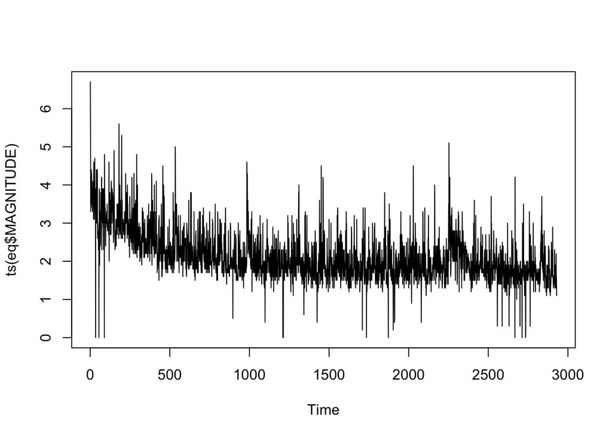

```r
# ii
plot(ts(eq$MAGNITUDE))
```

```r
median(eq$MAGNITUDE)
```

```
## [1] 2
```

## Question 7

1. Stratified random sampling
2. Fish in the Tennessee River
3. Capture location and species

## Question 8

1. Bar chart
2. Types of Robotic Limbs
3. Legs ONLY

```r
freq=c(15, 8, 63, 20)
RL=c("None", "Both", "Legs Only", "Wheels Only")
table(rep(RL, freq)) / sum(freq)
```

```
##
##        Both   Legs Only        None Wheels Only
##   0.0754717   0.5943396   0.1415094   0.1886792
```

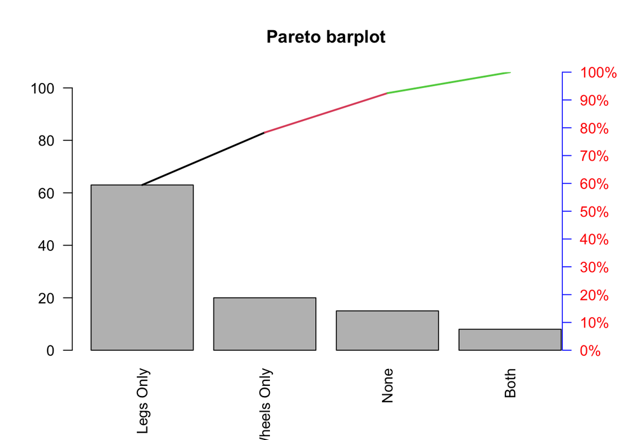

```r
pareto(rep(RL, freq))
```

## Question 9

1. Explorer

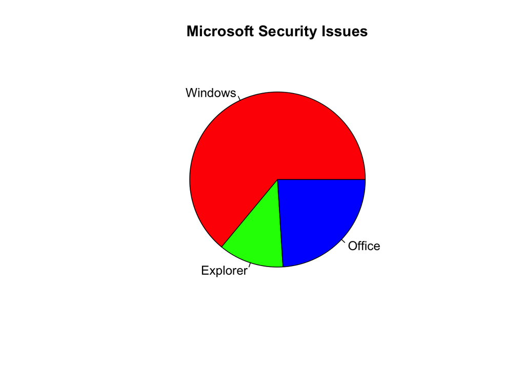

```r
products = c("Windows" = 32, "Explorer" = 6, "Office" = 12)
pie(products,
    main="Microsoft Security Issues",
    col=rainbow(length(products))
)
```

2. Remote Code Execution

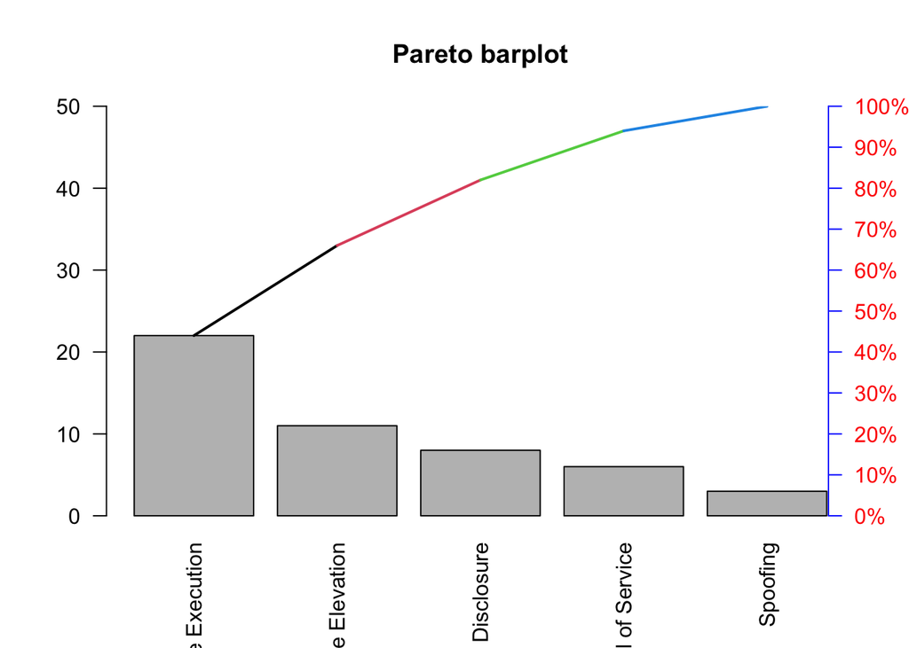

```r
freq = c(6, 8, 22, 3, 11)
categories = c("Denial of Service", "Information Disclosure", "Remote Code Execution", "Spoofing", "Privilege Elevation")
pareto(rep(categories, freq))
```

## Question 10

```r
head(swd)
```

```
##   Mloc Mvg Mevg Mivg   Hn  Hvol Hpgmlen Hdiff Hintell Heffort   Hb Htime Hloc
## 1  1.1 1.4  1.4  1.4  1.3   1.3    1.30  1.30    1.30       1 1.30     1    2
## 2  1.0 1.0  1.0  1.0  1.0   1.0    1.00  1.00    1.00       1 1.00     1    1
## 3 24.0 5.0  1.0  3.0 63.0 309.1    0.11  9.50   32.54    2937 0.10   163    1
## 4 20.0 4.0  4.0  2.0 47.0 215.5    0.06 16.00   13.47    3448 0.07   192    0
## 5 24.0 6.0  6.0  2.0 72.0 346.1    0.06 17.33   19.97    6000 0.12   333    0
## 6 24.0 6.0  6.0  2.0 72.0 346.1    0.06 17.33   19.97    6000 0.12   333    0
##   Hcomm Hblank loc.comm uniOp uniOpnd totOp totOpnd brnchcnt defect
## 1     2      2        2   1.2     1.2   1.2     1.2      1.4  FALSE
## 2     1      1        1   1.0     1.0   1.0     1.0      1.0   TRUE
## 3     0      6        0  15.0    15.0  44.0    19.0      9.0  FALSE
## 4     0      3        0  16.0     8.0  31.0    16.0      7.0  FALSE
## 5     0      3        0  16.0    12.0  46.0    26.0     11.0  FALSE
## 6     0      3        0  16.0    12.0  46.0    26.0     11.0  FALSE
##   predict.vg.10 predict.evg.14.5 predict.ivg.9.2 predict.loc.50
## 1            no               no              no             no
## 2            no               no              no             no
## 3            no               no              no             no
## 4            no               no              no             no
## 5            no               no              no             no
## 6            no               no              no             no
```

```r
tab=table(swd$defect)
rtab=tab/sum(tab)
round(rtab, 2)
```

```
##
## FALSE  TRUE
##   0.9   0.1
```

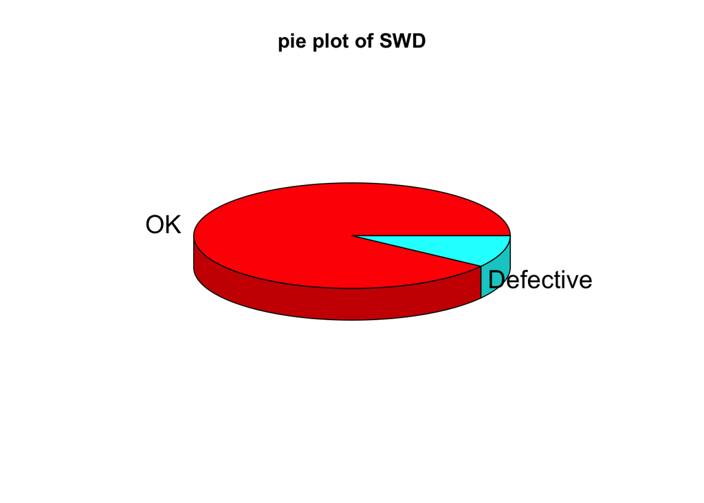

```r
pie3D(rtab, labels=list("OK", "Defective"), main="pie plot of SWD")
```

The module software code is most likely not going to be defective, but we can expect modules to be defective 10% of the time.

## Question 11

### a

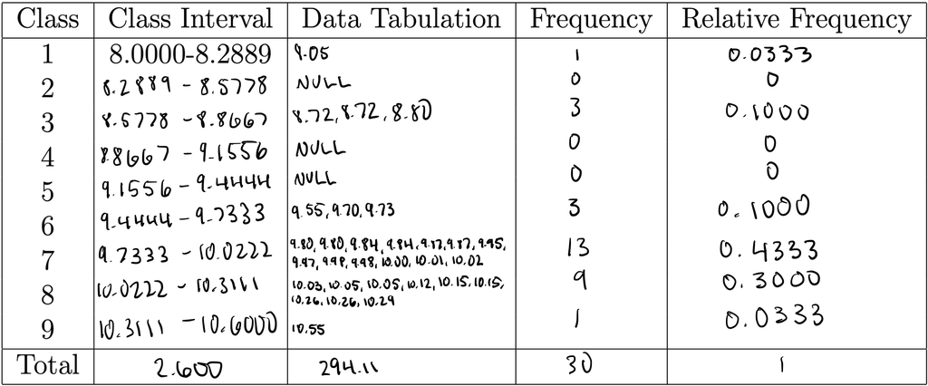

hand written histogram table thingy

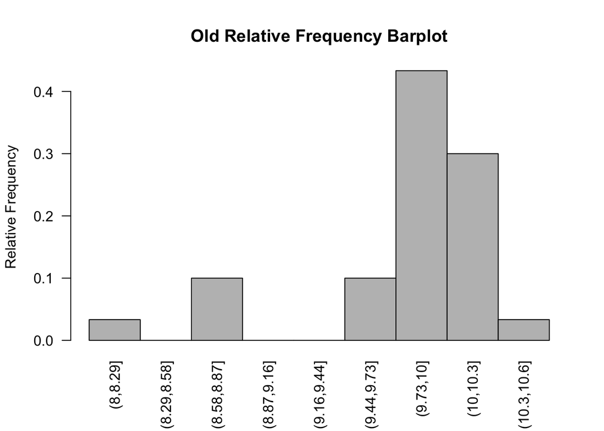

```r
old<-subset(volt,subset=LOCATION=="OLD")
old$VOLTAGE->vto
lept<-min(vto)-0.05
rept<-max(vto)+0.05
rnge<-rept-lept
inc<-rnge/9
seq(lept, rept,by=inc)->cl
cvto<-cut(vto,breaks=cl)
old.tab=table(cvto)
old.relative.freq <- old.tab / sum(old.tab)

# barplot for old relative frequency
barplot(old.relative.freq,space=0,main="Old Relative Frequency Barplot",las=2, ylab="Relative Frequency")
```

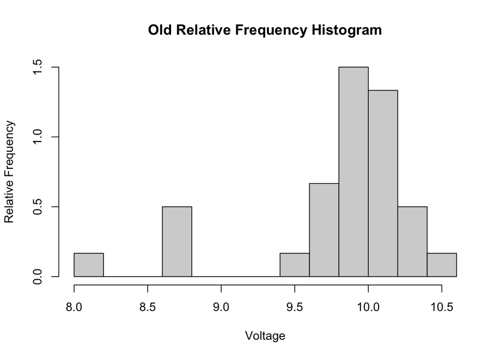

```r
# histogram for old relative frequency
hist(vto, prob=TRUE, nclass=10, xlab="Voltage", ylab="Relative Frequency", main="Old Relative Frequency Histogram")
```

### b

```r
stem((volt %>% filter(LOCATION == "OLD"))$VOLTAGE)
```

```
##
##   The decimal point is at the |
##
##    8 | 1
##    8 | 778
##    9 |
##    9 | 677888899
##   10 | 0000000011122333
##   10 | 6
```

The stem-and-leaf plot is more informative about where most of the voltage readings like because its much easier to see where the readings lie.

### c

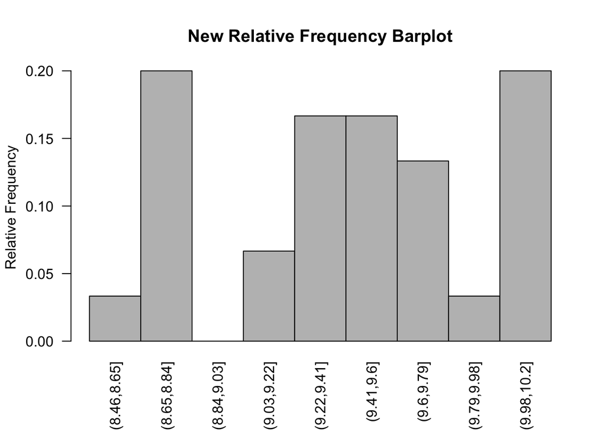

```r
new<-subset(volt,subset=LOCATION=="NEW")
new$VOLTAGE->vtn
lept<-min(vtn)-0.05
rept<-max(vtn)+0.05
rnge<-rept-lept
inc<-rnge/9
seq(lept, rept,by=inc)->cl
cvtn<-cut(vtn,breaks=cl)
new.tab=table(cvtn)
relative.freq <- new.tab / sum(new.tab)

# barplot for new relative frequency
barplot(relative.freq,space=0,main="New Relative Frequency Barplot",las=2, ylab="Relative Frequency")
```

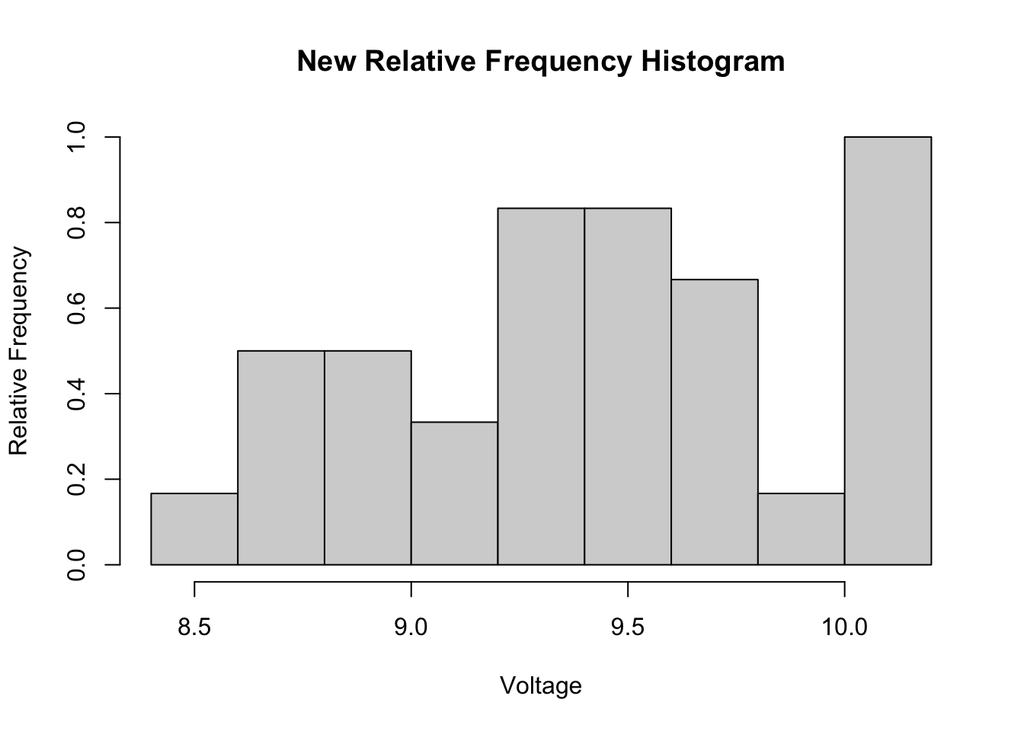

```r
# histogram for new relative frequency
hist(vtn, prob=TRUE, nclass=10, xlab="Voltage", ylab="Relative Frequency", main="New Relative Frequency Histogram")
```

### d

No, the new process is not as good as the old process. Most of the readings in the old location are above the 9.2/good process line whereas the new location is more dispersed.

### e

```r
# calculates average voltage in the old location
mean(vto)
```

```
## [1] 9.803667
```

```r
# calculates middle voltage in the old location
median(vto)
```

```
## [1] 9.975
```

```r
# calculates most common voltage in the old location
getmode(vto)
```

```
## [1] 9.98
```

```r
# calculates average voltage in the new location
mean(vtn)
```

```
## [1] 9.422333
```

```r
# calculates middle voltage in the new location
median(vtn)
```

```
## [1] 9.455
```

```r
# calculates most common voltage in the new location
getmode(vtn)
```

```
## [1] 8.82
```

### f

```r
(10.5-mean(vto))/sd(vto)
```

```
## [1] 1.287324
```

### g

```r
(10.5-mean(vtn))/sd(vtn)
```

```
## [1] 2.25041
```

### h

A voltage reading of 10.50 is more likely to occur at the old location because the z-score is lower (less standard deviations from the mean).

### i

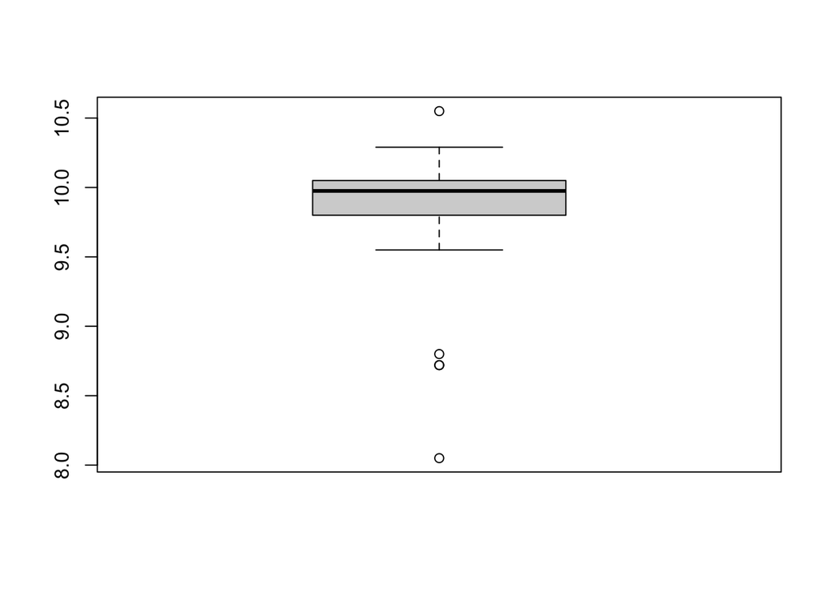

```r
boxplot((volt %>% filter(LOCATION == "OLD"))$VOLTAGE)
```

There are a few outliers in the old location

### j

```r
voltOld = (volt %>% filter(LOCATION == "OLD"))$VOLTAGE
voltOldZ = (voltOld - mean(voltOld)) / sd(voltOld)

voltOld[abs(voltOldZ) > 2]
```

```
## [1] 8.05 8.72 8.72
```

There are 3 outliers in the old location

### k

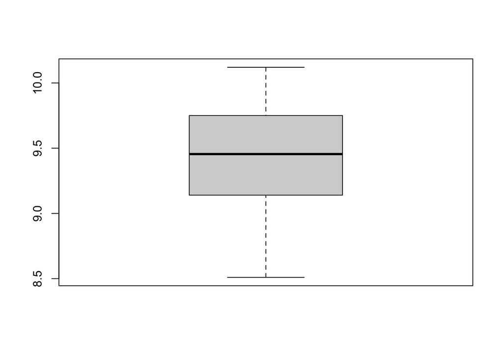

```r
boxplot((volt %>% filter(LOCATION == "NEW"))$VOLTAGE)
```

There seems to be no outliers at the new location

### l

```r
voltNew = (volt %>% filter(LOCATION == "NEW"))$VOLTAGE
voltNewZ = (voltNew - mean(voltNew)) / sd(voltNew)

voltNew[abs(voltNewZ) > 2]
```

```
## numeric(0)
```

There are no outliers at the new location

### m

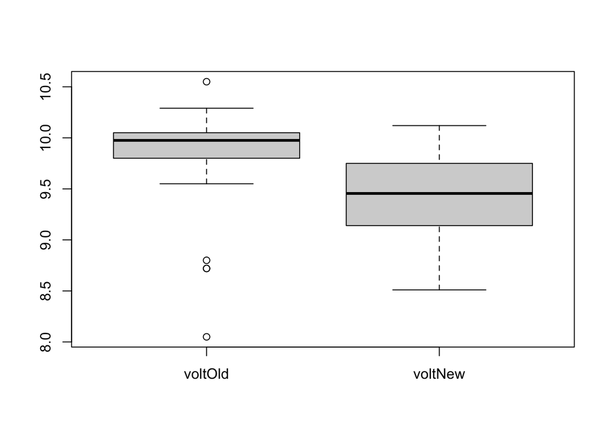

```r
boxplot(cbind(voltOld, voltNew))
```

The voltage readings at the old location are higher than the voltage readings at the new location, but the old location has more outliers.

## Question 12

```r
r=pipe$ROUGH
mean(r)
```

```
## [1] 1.881
```

```r
sd(r)
```

```
## [1] 0.5239114
```

$$\begin{eqnarray}
\bar{y} \pm 2s \\
1.881 \pm 2(0.524) \\
1.881 \pm 1.048 &=& (0.833, 2.929) \\
\end{eqnarray}$$

The interval that will likely contain about 95% of all coated pipe roughness measurements is (0.833, 2.929). 2 standard deviations are taken because approximate 95% of the data will fall within 2 standard deviations of the mean.

## Question 13

### a

```r
ant
```

```
##    Site      Region Rain Temp PlantCov AntSpecies Diversity
## 1     1  Dry Steppe  196  5.7       40          3      0.89
## 2     2  Dry Steppe  196  5.7       52          3      0.83
## 3     3  Dry Steppe  179  7.0       40         52      1.31
## 4     4  Dry Steppe  197  8.0       43          7      1.48
## 5     5  Dry Steppe  149  8.5       27          5      0.97
## 6     6 Gobi Desert  112 10.7       30         49      0.46
## 7     7 Gobi Desert  125 11.4       16          5      1.23
## 8     8 Gobi Desert   99 10.9       30          4        NA
## 9     9 Gobi Desert  125 11.4       56          4      0.76
## 10   10 Gobi Desert   84 11.4       22          5      1.26
## 11   11 Gobi Desert  115 11.4       14          4      0.69
```

```r
# average number ant species
mean(ant$AntSpecies)
```

```
## [1] 12.81818
```

```r
# number of ant species discovered at each site is around 5 ish
median(ant$AntSpecies)
```

```
## [1] 5
```

```r
# most common number of ant species discovered is 5
getmode(ant$AntSpecies)
```

```
## [1] 5
```

### b

I would recommend median because there are many outliers.

### c

```r
ds <- ant %>% filter(Region == "Dry Steppe")

mean(ds$PlantCov)
```

```
## [1] 40.4
```

```r
median(ds$PlantCov)
```

```
## [1] 40
```

```r
getmode(ds$PlantCov)
```

```
## [1] 40
```

### d

```r
gd <- ant %>% filter(Region == "Gobi Desert")

mean(gd$PlantCov)
```

```
## [1] 28
```

```r
median(gd$PlantCov)
```

```
## [1] 26
```

```r
getmode(gd$PlantCov)
```

```
## [1] 30
```

### e

Yes, the center of total plant coverage are different in the two regions. Dry Steppe centers around the 40s whereas Gobi Desert centers around the 25-30s.

## Question 14

### a

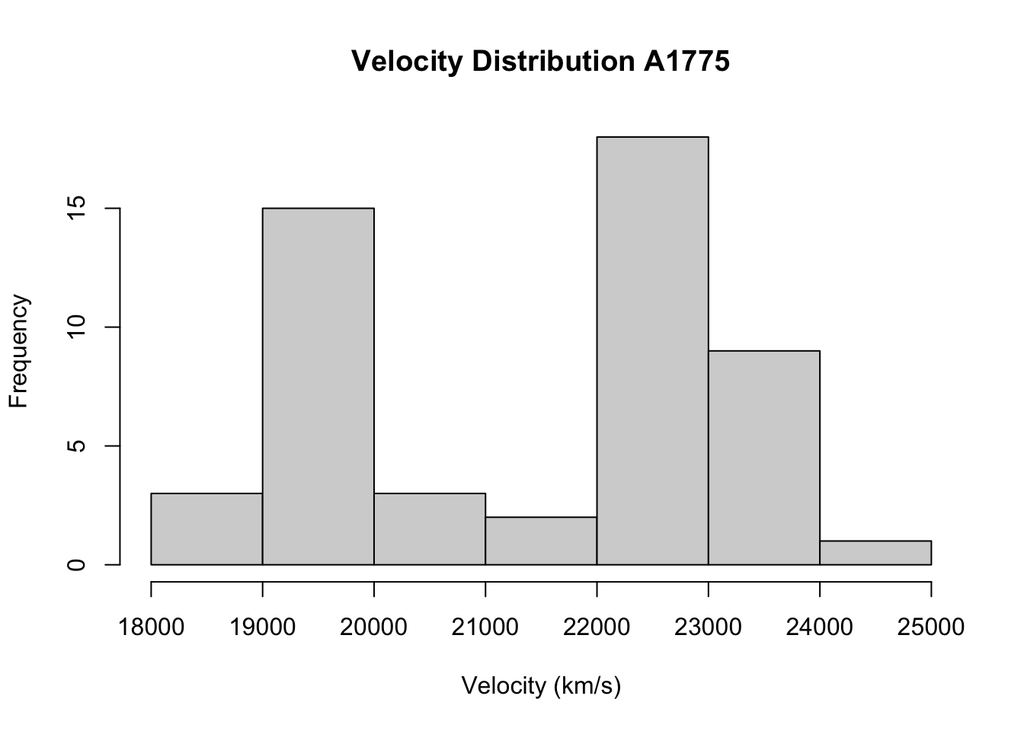

```r
hist(gal$VELOCITY,
     main="Velocity Distribution A1775",
     xlab="Velocity (km/s)")
```

### b

Yes, there are two peaks in the histogram which indicates there is evidence to support the double cluster theory.

### c

I am taking 21000 as the velocity to split the clusters.

```r
split = 21000

galA <- gal[gal$VELOCITY < split,]
galB <- gal[gal$VELOCITY >= split,]

# mean for first galaxy
mean(galA)
```

```
## [1] 19462.24
```

```r
# standard deviation for first galaxy
sd(galA)
```

```
## [1] 532.2868
```

```r
# mean for second galaxy
mean(galB)
```

```
## [1] 22838.47
```

```r
# standard deviation for second galaxy
sd(galB)
```

```
## [1] 560.9767
```

### d

```r
# z scores
(20000-mean(galA))/sd(galA)
```

```
## [1] 1.010286
```

```r
(20000-mean(galB))/sd(galB)
```

```
## [1] -5.059865
```

This galaxy is likely to belong to A1775A because 20,000 km/s is 1.01 sd away from A1775A, compared to 5.06 sd away from A1775B.

## Question 15

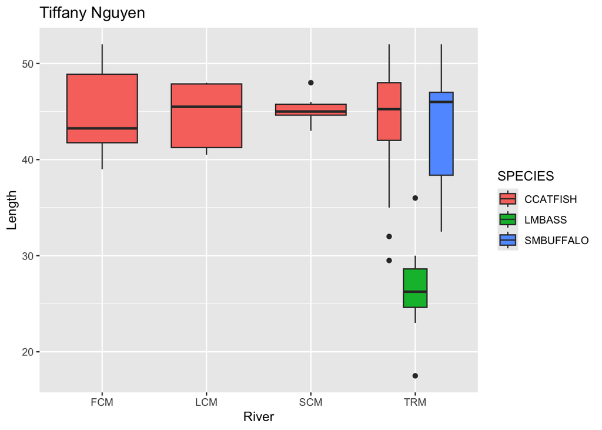

```r
ggplot(ddt, aes(x=RIVER, y=LENGTH, fill=SPECIES)) +
  geom_boxplot() +
  labs(title="Tiffany Nguyen",
       x="River",
       y="Length")
```